# Text Analytics (Northwestern University, MSIA 414)

## Notebook: Wine Reviews Example

## Yuri Balasanov, Leonid Nazarov, © iLykei 2018-2024

This notebook describes multiclass classification based on text description.

Data for this document can be downloaded from the [Kaggle competition web site](https://www.kaggle.com/christopheiv/winemagdata130k).

The goal is to identify wine producing country by analyzing text from a sommelier describing the wine's taste, smell, look, feel, etc.

# Word embeddings

Load the data.

```python
%matplotlib inline
import numpy as np
import pandas as pd
import pickle
from sklearn.preprocessing import LabelEncoder
from sklearn.model_selection import train_test_split
import os
from pathlib import Path
dataPath = Path(os.getcwd()).parent.parent.parent/"MEM"/"NLP"/"data"
reviews = pd.read_csv(dataPath/"winemag-data-130k-v2.csv", index_col=0)
reviews.head()
```

|  | country | description | designation | points | price | province | region_1 | region_2 | taster_name | taster_twitter_handle | title | variety | winery |
| --- | --- | --- | --- | --- | --- | --- | --- | --- | --- | --- | --- | --- | --- |
| 0 | Italy | Aromas include tropical fruit, broom, brimston... | Vulkà Bianco | 87 | NaN | Sicily & Sardinia | Etna | NaN | Kerin O’Keefe | @kerinokeefe | Nicosia 2013 Vulkà Bianco (Etna) | White Blend | Nicosia |
| 1 | Portugal | This is ripe and fruity, a wine that is smooth... | Avidagos | 87 | 15.0 | Douro | NaN | NaN | Roger Voss | @vossroger | Quinta dos Avidagos 2011 Avidagos Red (Douro) | Portuguese Red | Quinta dos Avidagos |
| 2 | US | Tart and snappy, the flavors of lime flesh and... | NaN | 87 | 14.0 | Oregon | Willamette Valley | Willamette Valley | Paul Gregutt | @paulgwine | Rainstorm 2013 Pinot Gris (Willamette Valley) | Pinot Gris | Rainstorm |
| 3 | US | Pineapple rind, lemon pith and orange blossom ... | Reserve Late Harvest | 87 | 13.0 | Michigan | Lake Michigan Shore | NaN | Alexander Peartree | NaN | St. Julian 2013 Reserve Late Harvest Riesling ... | Riesling | St. Julian |
| 4 | US | Much like the regular bottling from 2012, this... | Vintner's Reserve Wild Child Block | 87 | 65.0 | Oregon | Willamette Valley | Willamette Valley | Paul Gregutt | @paulgwine | Sweet Cheeks 2012 Vintner's Reserve Wild Child... | Pinot Noir | Sweet Cheeks |

Count number of wines from each country.

```python
reviews.country.value_counts().head()
```

```
country
US          54504
France      22093
Italy       19540
Spain        6645
Portugal     5691
Name: count, dtype: int64
```

The goal of the project is building a model separating US wines from Italian ones based on the vine reviews. Reduce data set leaving only US and Italian wines in it.

```python
Countries = ['US','Italy']
reviews = reviews[np.isin(reviews.country,Countries)][['description','country']]
reviews['country'] = LabelEncoder().fit_transform(reviews.country)
reviews.head()
```

|  | description | country |
| --- | --- | --- |
| 0 | Aromas include tropical fruit, broom, brimston... | 0 |
| 2 | Tart and snappy, the flavors of lime flesh and... | 1 |
| 3 | Pineapple rind, lemon pith and orange blossom ... | 1 |
| 4 | Much like the regular bottling from 2012, this... | 1 |
| 6 | Here's a bright, informal red that opens with ... | 0 |

# Words Polarity Analysis

Analyze words polarity like in MScA_32017_AMLAI_TC2_DataOverview.ipynb

Create tf-idf features for words from train data set comments with the following settings: max_features=50000, min_df=5, max_df=0.9.

```python
from sklearn.feature_extraction.text import TfidfVectorizer
tfidf = TfidfVectorizer(max_features=50000, min_df=5, max_df=0.9)
X = tfidf.fit_transform(reviews.description)
```

Fit logistic regression model taking these features as regressors and 'country' as target variable.

```python
from sklearn.linear_model import LogisticRegression
lr = LogisticRegression()
lr.fit(X, reviews['country'].values)
```

```
LogisticRegression()
```

Make data frame *polarity* with index containing all words from *TfidfVectorizer* *vocabulary_.keys()* and two columns. First of them contains corresponding *vocabulary_.values()*, the second one - logistic regression coefficients.

```python
polarity = pd.DataFrame.from_dict(tfidf.vocabulary_,orient='index')\
                                                    .sort_values(0)
polarity['coef'] = lr.coef_[0]
```

Sort data frame *polarity* according to coefficient value. Find 30 words with maximal coefficients and 30 words with minimal coefficients. Plot their coefficients with horizontal bars.

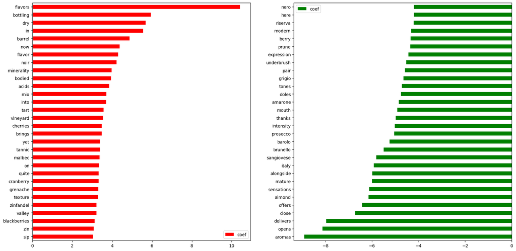

```python
from matplotlib import pyplot as plt
polarity.sort_values('coef',inplace=True)
plt.figure(figsize=(20, 10))
ax = plt.subplot(1,2,1)
polarity[['coef']].tail(30).plot(kind='barh', color='red', ax=ax)
ax = plt.subplot(1,2,2)
polarity[['coef']].head(30).plot(kind='barh', color='green', ax=ax)
```

Words from the right green plot correspond to Italian wines.

# Classification by logistic regression

Use the defined tf-idf feature `X` to predict the class.

```python
lr.predict(X)
```

```
array([0, 1, 1, ..., 0, 0, 1])
```

To predict probabilities by the logistic regression model `lr`, use `predict_proba()`.

```python
lr_predict_proba = lr.predict_proba(X)
lr_predict_proba[:3,:]
```

```
array([[0.89845819, 0.10154181],
       [0.00230428, 0.99769572],
       [0.03835437, 0.96164563]])
```

Finally, calculate the logloss metric of the prediction quality.

```python
from sklearn.metrics import log_loss
log_loss(reviews['country'].values, lr_predict_proba)
```

```
0.055808825909327675
```